# AN 588 Homework 2

Jimmy Erkens

2023-09-25

[figure not shown]

Cute Sleepy Coppery Titi Monkey

# 1 Libraries

Load in the necessary libraries:

```r
library(prettydoc)
library(yaml)
library(tidyverse)
library(tinytex) # install.packages("tinytex") <3
```

# 2 Questions

## 2.1 Initializations

The number of titi monkey calls in a 2 hour window is represented by X. X ~ Pois($\lambda$ = 15)

## 2.2 What is the probability that she will hear more than 8 calls during any given session?

We can use `ppois()` to find out cumulative probabilities!

```r
ppois(q = 7, lambda = 15, lower.tail = F) # NOTE lower.tail = F does not include 8, so we must start at 7
```

```
## [1] 0.9819978
```

## 2.3 What is the probability that she will hear no calls in a session?

Again, we can use `ppois()` to find out cumulative probablities!

```r
ppois(q = 0, lambda = 15, lower.tail = T) # 0 or less calls in a session
```

```
## [1] 3.059023e-07
```

The probability we hear 0 calls is 3.059 x 10^-7.

## 2.4 What is the probability that she will hear exactly 3 calls in a session?

```r
dpois(x = 3, lambda = 15) # why do we use dpois()
```

```
## [1] 0.0001720701
```

## 2.5 Plot the relevant Poisson mass function over the values in range 0 ≤ x ≤ 30.

```r
x <- seq(from = 1, to = 30, by = 1) # sequence from 1:30, we're gonna do dpois on each of these values
plot(dpois(x, lambda = 15)) # plot
xlab("Number of titi monkey calls in a 2 hour period") # labels
```

```
## $x
## [1] "Number of titi monkey calls in a 2 hour period"
##
## attr(,"class")
## [1] "labels"
```

```r
ylab("Probability")
```

```
## $y
## [1] "Probability"
##
## attr(,"class")
## [1] "labels"
```

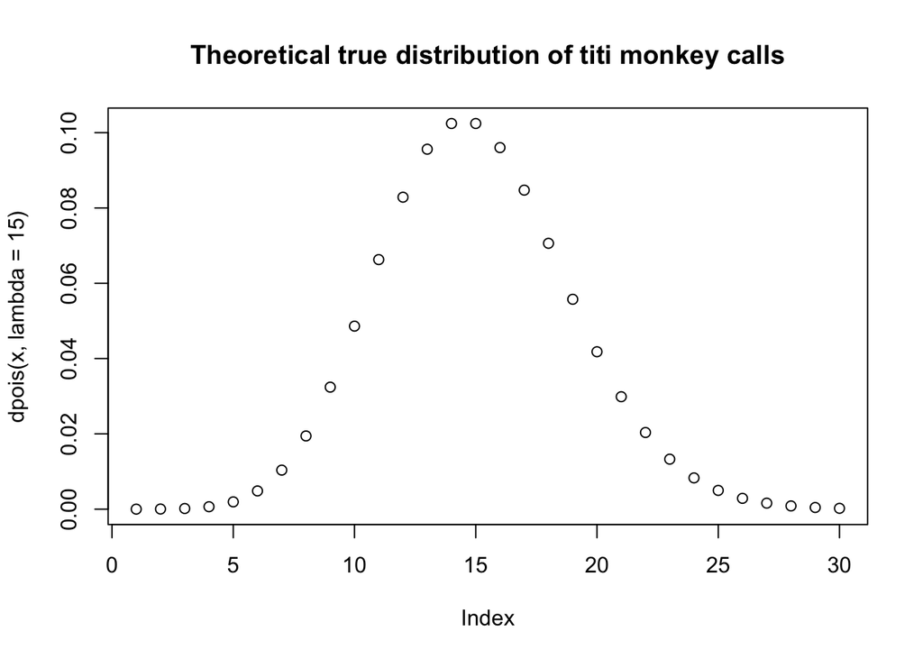

```r
title(main = "Theoretical true distribution of titi monkey calls") # title
```

## 2.6 Simulate 104 results from this distribution (i.e., 2 years of Saturday monitoring sessions).

We’re going to use `rpois()` to make this work.

```r
set.seed(812) # setting a seed, it's my birthday aww how cute
simulated_titi <- rpois(n = 104, lambda = 15) # we're gonna generate 104 values from a poisson(15)
```

## 2.7 Plot the simulated results using hist() and use xlim() to set the horizontal limits to be from 0 to 30. How does your histogram compare to the shape of the probability mass function you plotted above?

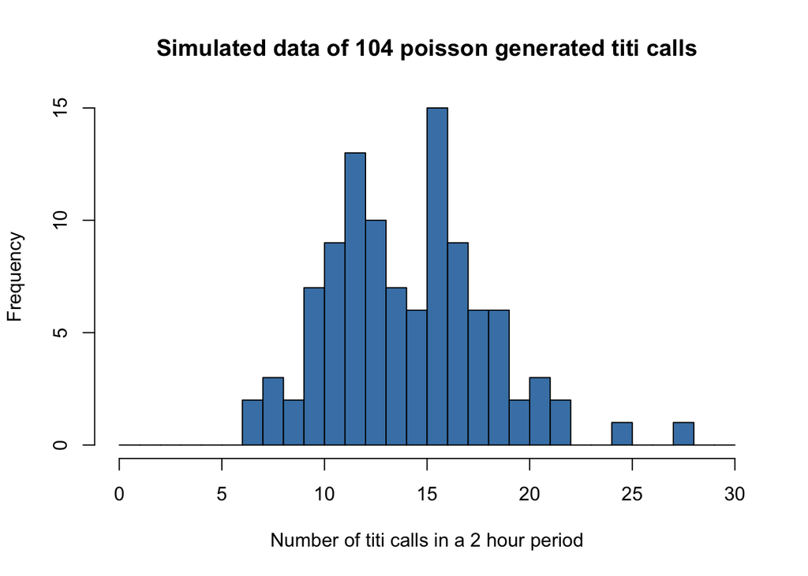

```r
hist(simulated_titi, xlim = range(0:30), breaks = 0:30, col = "steelblue",
xlab = "Number of titi calls in a 2 hour period",
main = "Simulated data of 104 poisson generated titi calls")
```

It looks somewhat similar to the theoretical model. However, because this is simulated data, it isn’t a perfect match! There are less values at x = 14 than we would expect, for example, and it seems there are a couple outliers.

# 3 Challenges I faced

1. I struggled with my `YAML` because I forgot to put “output:” in my header. I ended up copying and pasting a header I made at an earlier date, and realized my mistake.
2. I was struggling with adding the `cayman` theme to my document. I knit my document a few times and was failing to compile. I eventually pulled up an old stat homework and found the `prettydoc::pretty_html:` syntax.
3. I forgot the exact markdown syntax for inserting an image, so I looked it up and figured it out.
4. I needed to check how `lower.tail` functioned to ensure that I was including 8 calls (i.e., is this equal to or greater or just greater). I had to adjust my code because I initally had q = 8; I changed q = 7.
5. I forgot `hist()` and `plot()` had different arguments within the function. I had to take `xlab()` etc. and place within `hist()` argument.